# EXPLANATORY DATA ANALYSIS OF E-COMMERCE SALES PERFORMANCE: REVENUE, PROFITABILITY, PRODUCT CATEGORIES, GEOGRAPHIC TRENDS AND SALES TARGET ACHIEVEMENT USING PYTHON

## 1. Introduction

Multiple indicators of business performance involving sales, profit, products, geographical areas and performance, compared to business plans, are therefore required for effective business analysis (Enache, 2023). In the present project Python and Pandas will be used on a dataset from e-commerce representing a fictitious Indian e-commerce retailer. This bundles will be three related files and are List of Orders, Order details and Sales Target. This analysis is segmented into the following 5 business questions: Monthly revenue & profit performance, Product-category performance, sub-category profitability, geographic concentration of revenues and actual vs planned sales.

## 2. Business Context and Analytical Objectives

**The analysis is based on five questions:**  
Q1. In what way are revenues and profits effected with time?  
Q2. What is the best overall performer?  
Q3. What portion of the product categories makes or breaks the profits?  
Q4. Of all the states, which are the best at generating revenue?  
Q5. Are actualised selling figures at a level and pace to satisfy the projected selling level?

## 3. Data Exploration and Quality Assessment

Three CSV files were used: List of Orders, Order Details and Sales Target. The List of Orders had 560 rows and 500 rows actually had data in them – leaving 60 rows completely blank, which were eliminated. Order Details had 1,500 rows and 6 columns, and Sales Target had 36 rows and 3 columns. This attention to structure of data is crucial as it can affect further business analysis if the data is incorrectly duplicated or merged (Lin, 2025).

```python
!pip install -q kagglehub
```

```python
import os
import pandas as pd
import numpy as np
```

```python
import kagglehub

path = kagglehub.dataset_download("benroshan/ecommerce-data")
```

```
Downloading to /root/.cache/kagglehub/datasets/benroshan/ecommerce-data/2.archive...
```

```
Extracting files...
```

```python
orders = pd.read_csv(
    os.path.join(path, "List of Orders.csv")
)
```

```python
details = pd.read_csv(
    os.path.join(path, "Order Details.csv")
)
```

```python
targets = pd.read_csv(
    os.path.join(path, "Sales target.csv")
)
```

## 4. Data Preprocessing and Preparation

```python
orders_raw = orders.copy()
details_raw = details.copy()
targets_raw = targets.copy()
```

```python
orders = orders.dropna(how="all").copy()
details = details.dropna(how="all").copy()
targets = targets.dropna(how="all").copy()
```

```python
orders["Order Date"] = pd.to_datetime(
    orders["Order Date"],
    dayfirst=True,
    errors="coerce"
)
```

```python
orders = orders.sort_values(
    "Order Date"
).reset_index(drop=True)
```

```python
orders_clean = orders.copy()
details_clean = details.copy()
targets_clean = targets.copy()
```

```python
analysis_df = orders_clean.merge(
    details_clean,
    on="Order ID",
    how="inner"
)
```

```python
analysis_df["Month"] = (
    analysis_df["Order Date"]
    .dt.to_period("M")
    .dt.to_timestamp()
)
```

```python
analysis_df["Year"] = analysis_df["Order Date"].dt.year
analysis_df["Month_Number"] = analysis_df["Order Date"].dt.month
analysis_df["Month_Name"] = analysis_df["Order Date"].dt.strftime("%b")
```

## 5. Business Question 1 – Monthly Revenue and Profit Performance

### How does revenue and profit change over time?

It is important to look at revenue separately from the indicators as revenue indicates generation of sales while the rest shows the money earned in the dataset (Islam et al., 2025).

```python
monthly_performance = (
    analysis_df
    .groupby("Month", as_index=False)
    .agg(
        Revenue=("Amount", "sum"),
        Profit=("Profit", "sum")
    )
    .sort_values("Month")
)

display(monthly_performance)
```

|  | Month | Revenue | Profit |
| --- | --- | --- | --- |
| 0 | 2018-04-01 | 32726.0 | -3960.0 |
| 1 | 2018-05-01 | 28545.0 | -3584.0 |
| 2 | 2018-06-01 | 23658.0 | -4970.0 |
| 3 | 2018-07-01 | 12966.0 | -2138.0 |
| 4 | 2018-08-01 | 30899.0 | -2180.0 |
| 5 | 2018-09-01 | 26628.0 | -4963.0 |
| 6 | 2018-10-01 | 31615.0 | 3093.0 |
| 7 | 2018-11-01 | 48086.0 | 11619.0 |
| 8 | 2018-12-01 | 37579.0 | 5284.0 |
| 9 | 2019-01-01 | 61439.0 | 9760.0 |
| 10 | 2019-02-01 | 38424.0 | 5917.0 |
| 11 | 2019-03-01 | 58937.0 | 10077.0 |

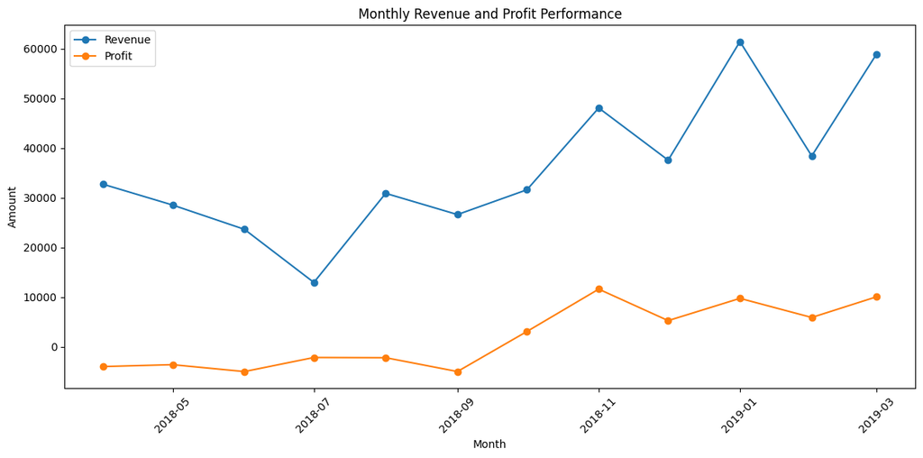

```python
import matplotlib.pyplot as plt

plt.figure(figsize=(12, 6))

plt.plot(
    monthly_performance["Month"],
    monthly_performance["Revenue"],
    marker="o",
    label="Revenue"
)

plt.plot(
    monthly_performance["Month"],
    monthly_performance["Profit"],
    marker="o",
    label="Profit"
)

plt.title("Monthly Revenue and Profit Performance")
plt.xlabel("Month")
plt.ylabel("Amount")
plt.xticks(rotation=45)
plt.legend()
plt.tight_layout()

plt.savefig(
    "/content/figure_1_monthly_revenue_profit.png",
    dpi=300,
    bbox_inches="tight"
)

plt.show()
```

## 6. Business Question 2 – Product Category Performance

### Which product category provides the strongest overall performance?

Revenue, profit and quantity are used to judge commercial performance (Enache, 2023).

```python
category_performance = (
    analysis_df
    .groupby("Category", as_index=False)
    .agg(
        Revenue=("Amount", "sum"),
        Profit=("Profit", "sum"),
        Quantity=("Quantity", "sum")
    )
    .sort_values("Revenue", ascending=False)
)

display(category_performance)
```

|  | Category | Revenue | Profit | Quantity |
| --- | --- | --- | --- | --- |
| 1 | Electronics | 165267.0 | 10494.0 | 1154 |
| 0 | Clothing | 139054.0 | 11163.0 | 3516 |
| 2 | Furniture | 127181.0 | 2298.0 | 945 |

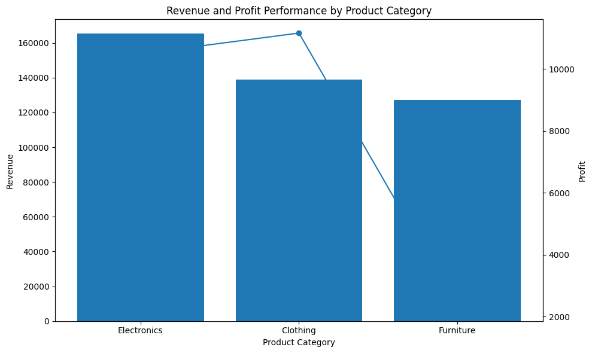

```python
fig, ax1 = plt.subplots(figsize=(10, 6))

ax1.bar(
    category_performance["Category"],
    category_performance["Revenue"],
    label="Revenue"
)

ax1.set_xlabel("Product Category")
ax1.set_ylabel("Revenue")

ax1.set_title(
    "Revenue and Profit Performance by Product Category"
)

ax2 = ax1.twinx()

ax2.plot(
    category_performance["Category"],
    category_performance["Profit"],
    marker="o",
    label="Profit"
)

ax2.set_ylabel("Profit")

fig.tight_layout()

plt.savefig(
    "/content/figure_2_category_revenue_profit.png",
    dpi=300,
    bbox_inches="tight"
)

plt.show()
```

**Figure 2. Revenue and Profit Performance by Product Category**  
Electronics was the highest earner with 165,267 followed by Clothing, with 139,054 and Furniture, with 127,181. The clothing segment sold the most with the highest profit at 11,163, Electronics came second with a profit of 10,494 while furniture sold the least with the lowest profit of 2,298 (Enache 2023).

## 7. Business Question 3 – Sub-Category Profitability

### Which product sub-categories generate or destroy profit?

```python
subcategory_profit = (
    analysis_df
    .groupby("Sub-Category", as_index=False)
    .agg(
        Profit=("Profit", "sum")
    )
    .sort_values("Profit", ascending=False)
)

display(subcategory_profit)
```

|  | Sub-Category | Profit |
| --- | --- | --- |
| 9 | Printers | 5964.0 |
| 1 | Bookcases | 4888.0 |
| 0 | Accessories | 3559.0 |
| 16 | Trousers | 2847.0 |
| 13 | Stole | 2559.0 |
| 8 | Phones | 2207.0 |
| 5 | Hankerchief | 2098.0 |
| 14 | T-shirt | 1500.0 |
| 11 | Shirt | 1131.0 |
| 4 | Furnishings | 844.0 |
| 2 | Chairs | 577.0 |
| 10 | Saree | 352.0 |
| 7 | Leggings | 260.0 |
| 12 | Skirt | 235.0 |
| 6 | Kurti | 181.0 |
| 3 | Electronic Games | -1236.0 |
| 15 | Tables | -4011.0 |

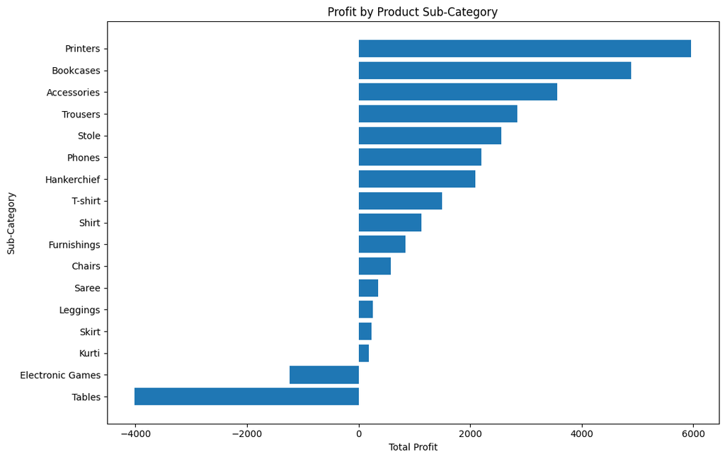

```python
plt.figure(figsize=(11, 7))

plt.barh(
    subcategory_profit["Sub-Category"],
    subcategory_profit["Profit"]
)

plt.title("Profit by Product Sub-Category")
plt.xlabel("Total Profit")
plt.ylabel("Sub-Category")

plt.gca().invert_yaxis()

plt.tight_layout()

plt.savefig(
    "/content/figure_3_subcategory_profit.png",
    dpi=300,
    bbox_inches="tight"
)

plt.show()
```

## 8. Business Question 4 – Geographic Revenue Performance

### Which states represent the strongest revenue markets?

Geographic analysis can be used to ascertain where revenues are located (Gino 2025).

```python
state_performance = (
    analysis_df
    .groupby("State", as_index=False)
    .agg(
        Quantity=("Quantity", "sum"),
        Revenue=("Amount", "sum"),
        Profit=("Profit", "sum")
    )
    .sort_values("Revenue", ascending=False)
)

display(state_performance)
```

|  | State | Quantity | Revenue | Profit |
| --- | --- | --- | --- | --- |
| 10 | Madhya Pradesh | 1360 | 105140.0 | 5551.0 |
| 11 | Maharashtra | 1056 | 95348.0 | 6176.0 |
| 2 | Delhi | 277 | 22531.0 | 2987.0 |
| 17 | Uttar Pradesh | 288 | 22359.0 | 3237.0 |
| 14 | Rajasthan | 282 | 21149.0 | 1257.0 |
| 4 | Gujarat | 328 | 21058.0 | 465.0 |
| 13 | Punjab | 216 | 16786.0 | -609.0 |
| 8 | Karnataka | 180 | 15058.0 | 645.0 |
| 18 | West Bengal | 216 | 14086.0 | 2500.0 |
| 9 | Kerala | 157 | 13459.0 | 1871.0 |
| 0 | Andhra Pradesh | 146 | 13256.0 | -496.0 |
| 1 | Bihar | 206 | 12943.0 | -321.0 |
| 12 | Nagaland | 173 | 11903.0 | 148.0 |
| 7 | Jammu and Kashmir | 177 | 10829.0 | 8.0 |
| 5 | Haryana | 111 | 8863.0 | 1325.0 |
| 6 | Himachal Pradesh | 113 | 8666.0 | 656.0 |
| 3 | Goa | 145 | 6705.0 | 370.0 |
| 16 | Tamil Nadu | 91 | 6087.0 | -2216.0 |
| 15 | Sikkim | 93 | 5276.0 | 401.0 |

```python
top_states = (
    state_performance
    .head(10)
    .sort_values("Revenue")
)

display(top_states)
```

|  | State | Quantity | Revenue | Profit |
| --- | --- | --- | --- | --- |
| 9 | Kerala | 157 | 13459.0 | 1871.0 |
| 18 | West Bengal | 216 | 14086.0 | 2500.0 |
| 8 | Karnataka | 180 | 15058.0 | 645.0 |
| 13 | Punjab | 216 | 16786.0 | -609.0 |
| 4 | Gujarat | 328 | 21058.0 | 465.0 |
| 14 | Rajasthan | 282 | 21149.0 | 1257.0 |
| 17 | Uttar Pradesh | 288 | 22359.0 | 3237.0 |
| 2 | Delhi | 277 | 22531.0 | 2987.0 |
| 11 | Maharashtra | 1056 | 95348.0 | 6176.0 |
| 10 | Madhya Pradesh | 1360 | 105140.0 | 5551.0 |

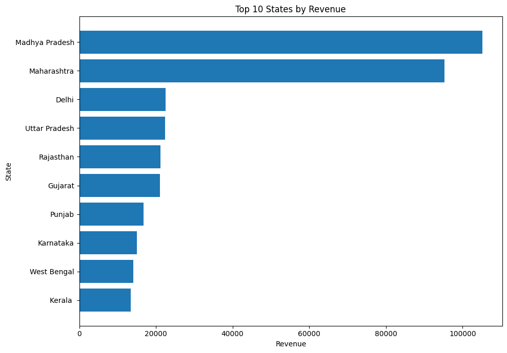

```python
plt.figure(figsize=(10, 7))

plt.barh(
    top_states["State"],
    top_states["Revenue"]
)

plt.title("Top 10 States by Revenue")
plt.xlabel("Revenue")
plt.ylabel("State")

plt.tight_layout()

plt.savefig(
    "/content/figure_4_top_10_states_revenue.png",
    dpi=300,
    bbox_inches="tight"
)

plt.show()
```

**Figure 4. Top 10 States by Revenue**  
Madhya Pradesh has earned the highest revenue of 105,140 followed by Maharashtra with 95,348. The two of these states accounted for 200,488 which made up a significant share of the geographic analysis revenue (Gino, 2025).

## 9. Business Question 5 – Actual Sales versus Target

### Is actual monthly sales performance meeting the planned target?

Comparing actual sales with planned targets helps management evaluate performance against goals (Valdez, 2026).

```python
targets_clean["Month"] = pd.to_datetime(
    targets_clean["Month of Order Date"],
    format="%b-%y",
    errors="coerce"
)
```

```python
actual_month_category = (
    analysis_df
    .groupby(
        ["Month", "Category"],
        as_index=False
    )
    .agg(
        Actual_Sales=("Amount", "sum")
    )
)
```

```python
target_month_category = (
    targets_clean[
        ["Month", "Category", "Target"]
    ]
    .copy()
)
```

```python
target_comparison = actual_month_category.merge(
    target_month_category,
    on=["Month", "Category"],
    how="left"
)
```

```python
target_comparison["Variance"] = (
    target_comparison["Actual_Sales"]
    - target_comparison["Target"]
)

target_comparison["Achievement_Percentage"] = (
    target_comparison["Actual_Sales"]
    / target_comparison["Target"]
    * 100
)
```

```python
monthly_target_comparison = (
    target_comparison
    .groupby("Month", as_index=False)
    .agg(
        Actual_Sales=("Actual_Sales", "sum"),
        Target=("Target", "sum")
    )
    .sort_values("Month")
)

display(monthly_target_comparison)
```

|  | Month | Actual_Sales | Target |
| --- | --- | --- | --- |
| 0 | 2018-04-01 | 32726.0 | 31400.0 |
| 1 | 2018-05-01 | 28545.0 | 31500.0 |
| 2 | 2018-06-01 | 23658.0 | 31600.0 |
| 3 | 2018-07-01 | 12966.0 | 33800.0 |
| 4 | 2018-08-01 | 30899.0 | 33900.0 |
| 5 | 2018-09-01 | 26628.0 | 34000.0 |
| 6 | 2018-10-01 | 31615.0 | 36100.0 |
| 7 | 2018-11-01 | 48086.0 | 36300.0 |
| 8 | 2018-12-01 | 37579.0 | 36400.0 |
| 9 | 2019-01-01 | 61439.0 | 43500.0 |
| 10 | 2019-02-01 | 38424.0 | 43600.0 |
| 11 | 2019-03-01 | 58937.0 | 43800.0 |

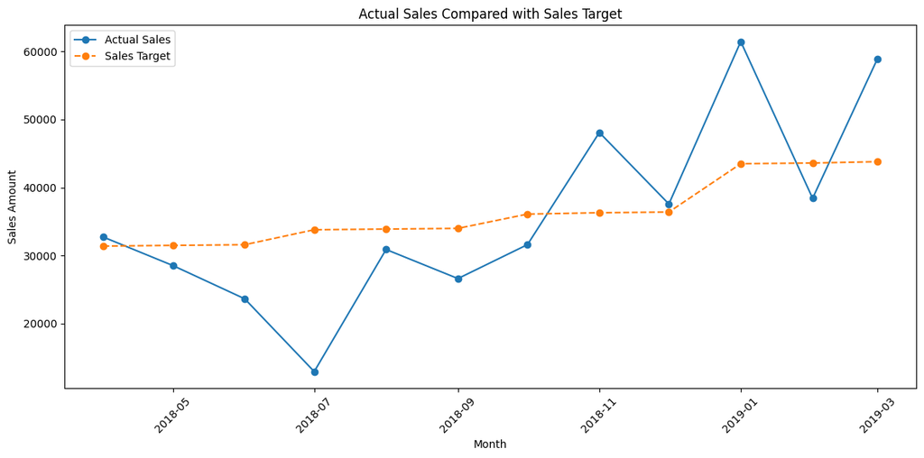

```python
plt.figure(figsize=(12, 6))

plt.plot(
    monthly_target_comparison["Month"],
    monthly_target_comparison["Actual_Sales"],
    marker="o",
    label="Actual Sales"
)

plt.plot(
    monthly_target_comparison["Month"],
    monthly_target_comparison["Target"],
    marker="o",
    linestyle="--",
    label="Sales Target"
)

plt.title("Actual Sales Compared with Sales Target")
plt.xlabel("Month")
plt.ylabel("Sales Amount")
plt.xticks(rotation=45)
plt.legend()

plt.tight_layout()

plt.savefig(
    "/content/figure_5_actual_vs_target.png",
    dpi=300,
    bbox_inches="tight"
)

plt.show()
```

**Figure 5. Actual Sales Compared with Sales Target**  
Sales were above target for the months of April, November, December, January and March. January is the best month compared against the actual and target sales; the actual number of sales was 61,439 while the expected number of sales was 43,500, a positive variance of 17,939 (Weber, 2023).

```python
import os
import shutil

figure_folder = "/content/M504_Report_Figures"

os.makedirs(figure_folder, exist_ok=True)
```

```python
figure_files = [
    "figure_1_monthly_revenue_profit.png",
    "figure_2_category_revenue_profit.png",
    "figure_3_subcategory_profit.png",
    "figure_4_top_10_states_revenue.png",
    "figure_5_actual_vs_target.png"
]

for file in figure_files:
    source = f"/content/{file}"
    destination = os.path.join(figure_folder, file)

    if os.path.exists(source):
        shutil.copy(source, destination)
```

```python
shutil.make_archive(
    "/content/M504_Report_Figures",
    "zip",
    figure_folder
)
```

```
'/content/M504_Report_Figures.zip'
```

## 10. Overall Discussion and Business Implications

Revenue and profitability are not synonymous: Electronics achieved the highest revenue figure but Clothing achieved the highest profit figure (Enache, 2023). Profits are positive for Printers and Bookcases and negative for Tables and Electronic Games (Imran et al., 2025). There is great concentration of revenue in Madhya Pradesh and Maharashtra (Raktate and Das, 2026). This data is only from a single year and no causal modelling or machine-learning prediction was done (Norouzi, 2024).

## References

Islam, M.R., Hossain, M., Alam, M., Khan, M.M., Rabbi, M.M.K., Rabby, M.F., Tarafder, M.T.R., Bishnu, K.K. and Das, B.C., 2025. Leveraging Machine Learning for Insights and Predictions in Synthetic E-Commerce Data in the USA: A Comprehensive Analysis. Journal of Ecohumanism, 4(2), pp.2394-2420. https://www.researchgate.net/profile/Mahfuz-Alam-11/publication/392764591_Leveraging_Machine_Learning_for_Insights_and_Predictions_in_Synthetic_E-_Commerce_Data_in_the_USA_A_Comprehensive_Analysis/links/68521fbbdf3fa4286a413e58/Leveraging-Machine-Learning-for-Insights-and-Predictions-in-Synthetic-E-Commerce-Data-in-the-USA-A-Comprehensive-Analysis.pdf  
Raktate, S. and Das, A., 2026. Big Data Analytics in Indian E-Commerce: A Comprehensive Case Study of Flipkart's Data-Driven Architecture and Strategy. https://ijcope.org/wp-content/uploads/2026/05/Big-Data-Analytics-in-Indian-E-Commerce-A-Comprehensive-Case-Study.pdf  
Zeinali, M., Ramezani Asli, L. and Khalili, M.A., 2026. Integrating Business Intelligence and CRM Systems With a Machine Learning Approach for Predictive Customer Retention in E‐Commerce. The Scientific World Journal, 2026(1), p.1946904. https://onlinelibrary.wiley.com/doi/pdf/10.1155/tswj/1946904  
ENACHE, M.C., 2023. Data Analysis in e-Commerce. Economics and Applied Informatics Journal, (1), pp.1584-0409. http://www.eia.feaa.ugal.ro/images/eia/2023_1/Enache2.pdf  
Valdez, B., 2026. Descriptive Analysis of E-Commerce Sales Performance: An End-to-End Analytics Dashboard Using PostgreSQL, Machine Learning, and Natural Language Querying. https://digitalcommons.ncf.edu/cgi/viewcontent.cgi?article=7921&context=theses_etds  
Imran, H.M., Islam, M.M., Shaharum, S.S., Ahmed, M.R. and Orthy, A.H., 2025. Data-Driven Business Analysis: A Comprehensive Analysis of Predictive Analytics in Pricing Strategies, Marketing Decisions and Operational Efficiency. Review of Applied Science and Technology, 4(02), pp.616-638. https://rast-journal.org/index.php/RAST/article/download/39/40  
Shafa, H., 2022. Integration Of Machine Learning and Advanced Computing For Optimizing Retail Customer Analytics. International Journal of Business and Economics Insights, 2(3), pp.01-46. https://ijbei-journal.org/index.php/ijbei/article/download/37/37  
Rosa, L.G.C., 2025. Retail Demand Forecasting and Channel Cannibalization: an Empirical Analysis using Gradient Boosting Models. https://repositorio.ufsc.br/bitstream/handle/123456789/271184/TCC.pdf?sequence=1  
Weber, F., 2023. Artificial intelligence for business analytics. Springer. https://bdbanalytics.ir/wp-content/uploads/2024/04/Felix-Weber-Artificial-Intelligence-for-Business-Analytics_-Algorithms-Platforms-and-Application-Scenarios-Springer-Vieweg-2023.pdf  
Patil, P.P., 2025. A Data-Driven Approach to Customer Segmentation and Customer Lifetime Value Prediction in Retail and E-Commerce (Doctoral dissertation, Dublin, National College of Ireland). https://norma.ncirl.ie/8608/1/prachipradeeppatil.pdf  
Hallimsyore Kalegowda, A., 2025. Utilizing Predictive Analytics to Enhance Retail Business Performance (Doctoral dissertation, Dublin, National College of Ireland). https://norma.ncirl.ie/7523/1/aravindhallimysorekalegowda.pdf  
TEENA, M., 2023. DESIGN AND IMPLEMENTATION OF PREDICTIVE DATA MINING TECHNIQUE FOR CUSTOMER PERCEPTION TOWARDS ONLINE AND OFFLINE SHOPPING (Doctoral dissertation, JAGANNATH UNIVERSITY). https://www.researchgate.net/profile/Teena-Vats-2/publication/380295282_DESIGN_AND_IMPLEMENTATION_OF_PREDICTIVE_DATA_MINING_TECHNIQUE_FOR_CUSTOMER_PERCEPTION_TOWARDS_ONLINE_AND_OFFLINE_SHOPPING_DOCTOR_OF_PHILOSOPHY_in_COMPUTER_SCIENCE_ENGINEERING_FACULTY_OF_ENGINEERING_TE/links/663475d806ea3d0b74239b2c/DESIGN-AND-IMPLEMENTATION-OF-PREDICTIVE-DATA-MINING-TECHNIQUE-FOR-CUSTOMER-PERCEPTION-TOWARDS-ONLINE-AND-OFFLINE-SHOPPING-DOCTOR-OF-PHILOSOPHY-in-COMPUTER-SCIENCE-ENGINEERING-FACULTY-OF-ENGINEERING.pdf  
Gino, H.L.S., 2025. Visual analytics tailored to support e-commerce marketplace advertising: The ecommvis platform (Doctoral dissertation, Universidade de São Paulo). https://teses.usp.br/teses/disponiveis/55/55134/tde-18112025-120315/publico/HenriqueLuizShibataGino_ME.pdf  
Dadiz, B., 2024. Design and Implementation of Big Data and Analytics to Enhance Dynamic Price Comparison Analytics of an e-Commerce Enterprise Company in Australia. https://uniselinus.co.uk/sites/default/files/2025-01/Bryan%20Dadiz.pdf  
Sumanth, T., Reshma, S.H.A.I.K., Ramu, K.A.L.I.G.I.R.I., Ram, T.K. and Rehan, S.M., 2025. Enhancing Retail Sales Predictions for Big Mart Using Advanced Machine Learning Techniques. INTERNATIONAL JOURNAL, 9(3). https://www.ijasret.com/VolumeArticles/FullTextPDF/1466_33.Enhancing_Retail_Sales_Predictions_for_Big_Mart_Using_Advanced_Machine_Learning_Techniques.pdf  
Sangoi, M.D., 2025. Retail Manufacturing Analysis using Machine Learning Techniques (Doctoral dissertation, Dublin, National College of Ireland). https://norma.ncirl.ie/7263/1/meetdeepensangoi.pdf  
Maliyekkal, C.D., 2025. Predicting Customer Lifetime Value (CLV) in UK and Brazil using Machine Learning and Deep Learning: A Comparative Analysis (Doctoral dissertation, Dublin, National College of Ireland). https://norma.ncirl.ie/7565/1/christydavismaliyekkal.pdf  
Muralidhar, S., 2025. Retail Price Optimization Using Machine Learning Algorithms (Doctoral dissertation, Dublin, National College of Ireland). https://norma.ncirl.ie/7572/1/snehamuralidhar.pdf  
Lin, K., 2025. Data-driven design for industrial applications (Doctoral dissertation, University of Illinois Urbana-Champaign). https://www.ideals.illinois.edu/items/139518/bitstreams/450540/data.pdf  
Norouzi, V., 2024. Predicting e-commerce CLV with neural networks: The role of NPS, ATV, and CES. Journal of Economy and Technology, 2, pp.174-189. https://www.sciencedirect.com/science/article/pii/S2949948824000222  
Md Abul Kalam, A., Rakib Hassan, R., Mohammad Rasel, M. and Sadia, A., 2024. Advancing the US business competitiveness through AI-driven predictive analytics to optimize operations and enhance strategic decision-making. American Journal of Technology Advancement, 1(7), pp.92-120. http://eprints.umsida.ac.id/16401/1/Advancing%20the%20U.S.%20Business%20Competitiveness.pdf

## Appendix

### Dataset:

**Link:** https://www.kaggle.com/datasets/benroshan/ecommerce-data/data  
**API:**

```
import kagglehub

# Download latest version
path = kagglehub.dataset_download("benroshan/ecommerce-data")

print("Path to dataset files:", path)
```